# Analyse des états des lieux réalisés dans le cadre de la DCE

Nicolas Poulet

2024-03-21

## Avant propos

Il s’agit de traiter les états des lieux faisant le bilan des pressions au cours des trois cycles de gestion 2010-2015, 2016-2021 et 2022-2027. L’état des lieux liste la présence de pressions significatives (i.e. risque de non atteinte du bon état) classées dans différentes catégories : pollution ponctuelle, pollution diffuse, hydrologie, hydromorphologie et gestion de l’eau. Chacune de ces catégories a été découpée en sous catégories. Cependant, ces sous-catégories ont évolué entre les cycle. Les données sont de type binaire (présence/absence).

Il s’agit ici de i) caractériser le degré de pression pour chaque masse d’eau et ii) caractériser la tendance temporelle de ce degré de pression. De fait, cette caractérisation a été effectuée au niveau des catégories dans la mesure où les sous- catégories n’étaient pas comparable entre les cycles.

## Préparation du jeu de données

## Traitement des données 2010

Le tableau intial contien les données de pression et d’impact.

| EURBDCode | RBDNameNL | EUSubUnitCode | SubUnitNameNL | EUSurfaceWaterBodyCode…5 | SWB_NAME | LAT | LON | CATEGORY | Natural | TypologyCode | ReferenceDataSet | AREA | LENGTH | Scale | ScaleExplanation | PROT_AREA_ASSOC | TargetStatusOrPotential | ValueEcologicalStatusOrPotential | Confidence | CommentConfidence | ValueQE1_1PhytoplanktonStatusOrPotential | ValueQE1_2OtherAquaticFloraStatusOrPotential | ValueQE1_2_1MacroalgaeStatusOrPotential | ValueQE1_2_2AngiospermsStatusOrPotential | ValueQE1_2_3MacropyhtesStatusOrPotential | ValueQE1_2_4PhytobenthosStatusOrPotential | ValueQE1_3MacroinvertabratesStatusOrPotential | ValueQE1_4FishStatusOrPotential | ValueQE1_5OtherBiologicalQEStatusOrPotential | … |
| --- | --- | --- | --- | --- | --- | --- | --- | --- | --- | --- | --- | --- | --- | --- | --- | --- | --- | --- | --- | --- | --- | --- | --- | --- | --- | --- | --- | --- | --- | --- |
| FRA | L’Escaut, la Somme et les cours d’eau côtiers de la Manche et de la mer du Nord | FRA_ESCA | Escaut | FRAC01 | Frontière belge Ã jetée de Malo | 51.0791 | 02.4317 | CW | Natural | C8 | N | 65.586969999999994 | NA | 1:50000 | NA | Y | S | 2 | 1 | NA | 2 | U | U | U | U | U | 2 | U | U | … |
| FRA | L’Escaut, la Somme et les cours d’eau côtiers de la Manche et de la mer du Nord | FRA_ESCA | Escaut | FRAC02 | Jetée de Malo Ã Est cap Griz nez | 51.0066 | 01.9920 | CW | Natural | C9 | N | 143.38844 | NA | 1:50000 | NA | Y | S | 2 | 1 | NA | 2 | U | U | U | U | U | 2 | U | U | … |
| FRA | L’Escaut, la Somme et les cours d’eau côtiers de la Manche et de la mer du Nord | FRA_ESCA | Escaut | FRAC03 | Cap Griz nez Ã Slack | 50.8144 | 01.5908 | CW | Natural | C1 | N | 25.10408 | NA | 1:50000 | NA | Y | S | 3 | 1 | NA | 3 | U | U | U | U | U | 2 | U | U | … |
| FRA | L’Escaut, la Somme et les cours d’eau côtiers de la Manche et de la mer du Nord | FRA_ESCA | Escaut | FRAC04 | Slack Ã la Warenne | 50.7160 | 01.5726 | CW | Natural | C9 | N | 35.825420000000001 | NA | 1:50000 | NA | Y | S | 3 | 1 | NA | 3 | U | U | U | U | U | 2 | U | U | … |
| FRA | L’Escaut, la Somme et les cours d’eau côtiers de la Manche et de la mer du Nord | FRA_ESCA | Escaut | FRAC05 | La Warenne Ã Ault | 50.3286 | 01.5328 | CW | Natural | C9 | N | 233.30224999999999 | NA | 1:50000 | NA | Y | S | 3 | 1 | NA | 4 | U | U | U | U | U | 2 | U | U | … |
| FRA | L’Escaut, la Somme et les cours d’eau côtiers de la Manche et de la mer du Nord | FRA_ESCA | Escaut | FRAL01 | ETANGS DU ROMELAERE | 50.7821 | 02.2849 | LW | Heavily Modified | A13b | U | 0.58675999999999995 | NA | 1:50000 | NA | Y | P | 3 | 1 | Le potentiel écologique est déterminé Ã dire d’expert | U | U | U | U | U | U | U | U | U | … |

On ne traite que les données de pressions. On sélectionne les masses d’eau type “cours d’eau” (RW) et naturelles (natural). On transforme les données en 1/0. On agrège les pressions par catégorie, on ajoute un champ “année” et le champ contenant le code unique de chaque masse d’eau

| année | code_wb | 1. pollution ponctuelle | 2. Pollution diffuse | 3. hydrologie | 4. hydromorpho | 5. gestion eau | 6. gestion eau transition | 7. autres altération morpho | 8. autres pressions |
| --- | --- | --- | --- | --- | --- | --- | --- | --- | --- |
| 2010 | FRAR02 | 1 | 1 | 0 | 1 | 1 | 0 | 0 | 0 |
| 2010 | FRAR03 | 1 | 1 | 0 | 1 | 1 | 0 | 0 | 0 |
| 2010 | FRAR04 | 1 | 1 | 0 | 1 | 1 | 0 | 0 | 0 |
| 2010 | FRAR05 | 0 | 1 | 0 | 1 | 1 | 0 | 0 | 0 |
| 2010 | FRAR06 | 1 | 1 | 0 | 1 | 1 | 0 | 0 | 0 |
| 2010 | FRAR07 | 1 | 1 | 0 | 1 | 1 | 0 | 0 | 0 |

| année | code_wb | 1. pollution ponctuelle | 2. Pollution diffuse | 3. hydrologie | 4. hydromorpho | 5. gestion eau | 6. gestion eau transition | 7. autres altération morpho | 8. autres pressions |
| --- | --- | --- | --- | --- | --- | --- | --- | --- | --- |
| 2016 | FRAC01 | 0 | 1 | 0 | 0 | 0 | 0 | 0 | 0 |
| 2016 | FRAC02 | 0 | 1 | 0 | 0 | 0 | 0 | 0 | 0 |
| 2016 | FRAC03 | 0 | 1 | 0 | 0 | 0 | 0 | 0 | 0 |
| 2016 | FRAC04 | 0 | 1 | 0 | 0 | 0 | 0 | 0 | 0 |
| 2016 | FRAC05 | 0 | 1 | 0 | 0 | 0 | 0 | 0 | 0 |
| 2016 | FRAL01 | 0 | 1 | 0 | 0 | 0 | 0 | 0 | 0 |

Puis pour l’année 2022 (données encore présentées différement)

| année | code_wb | 1. pollution ponctuelle | 2. Pollution diffuse | 3. hydrologie | 4. hydromorpho | 5. gestion eau | 6. gestion eau transition | 7. autres altération morpho | 8. autres pressions |
| --- | --- | --- | --- | --- | --- | --- | --- | --- | --- |
| 2022 | FRAR55 | 0 | 1 | 0 | 1 | 0 | 0 | 0 | 0 |
| 2022 | FRAL01 | 1 | 1 | 0 | 1 | 0 | 0 | 0 | 0 |
| 2022 | FRAR61 | 1 | 1 | 0 | 1 | 0 | 0 | 0 | 0 |
| 2022 | FRAR01 | 1 | 1 | 0 | 1 | 0 | 0 | 0 | 0 |
| 2022 | FRAR05 | 0 | 1 | 0 | 1 | 0 | 0 | 0 | 0 |
| 2022 | FRAC01 | 1 | 1 | 0 | 0 | 0 | 0 | 0 | 0 |

On aggrège les 3 années en ne conservant que les masse d’eau communes aux 3 jeux de données et ayant été évaluées les 3 années de sorte à avoir 3 évaluations pour chaque masse d’eau pour les 3 années. On élimine les pressions pour lesquelles aucune des masses d’eau n’est concernée. De fait, on garde que 5 pressions.

| année | code_wb | 1. pollution ponctuelle | 2. Pollution diffuse | 3. hydrologie | 4. hydromorpho | 5. gestion eau |
| --- | --- | --- | --- | --- | --- | --- |
| 2010 | FRAR02 | 1 | 1 | 0 | 1 | 1 |
| 2010 | FRAR03 | 1 | 1 | 0 | 1 | 1 |
| 2010 | FRAR04 | 1 | 1 | 0 | 1 | 1 |
| 2010 | FRAR05 | 0 | 1 | 0 | 1 | 1 |
| 2010 | FRAR06 | 1 | 1 | 0 | 1 | 1 |
| 2010 | FRAR07 | 1 | 1 | 0 | 1 | 1 |

## Analyse des données

On analyse ce jeu de donnée d’abord toutes pressions confondues puis en distingant les pressions physiques des pressions chimiques.

Il s’agit de réaliser une ACP centrée puis de récupérer les scores des masses d’eau sur l’axe 1 pour calculer la moyenne de ce score pour les 3 années ce qui donne un indice de pression, puis la pente de la droite entre le score et les années de façon à évaluer la tendance de chaque masse d’eau en terme de pression.

### Toutes pressions confondues

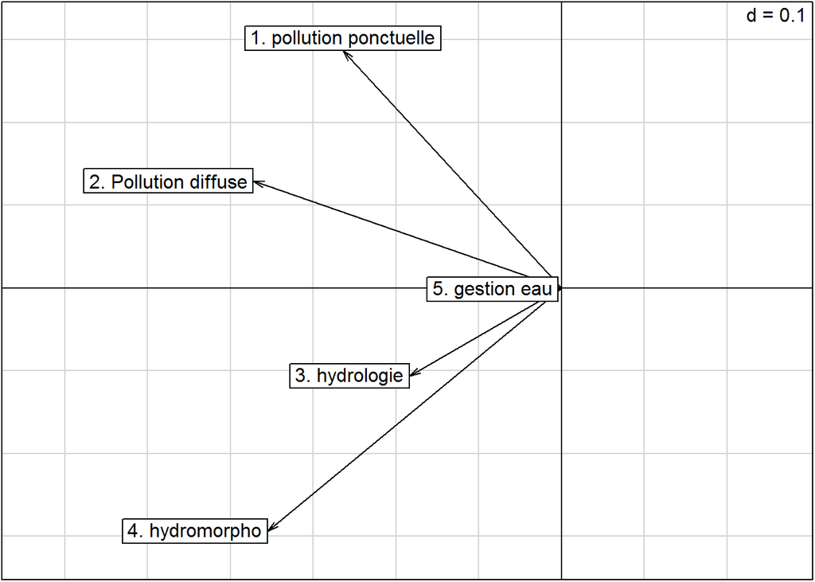

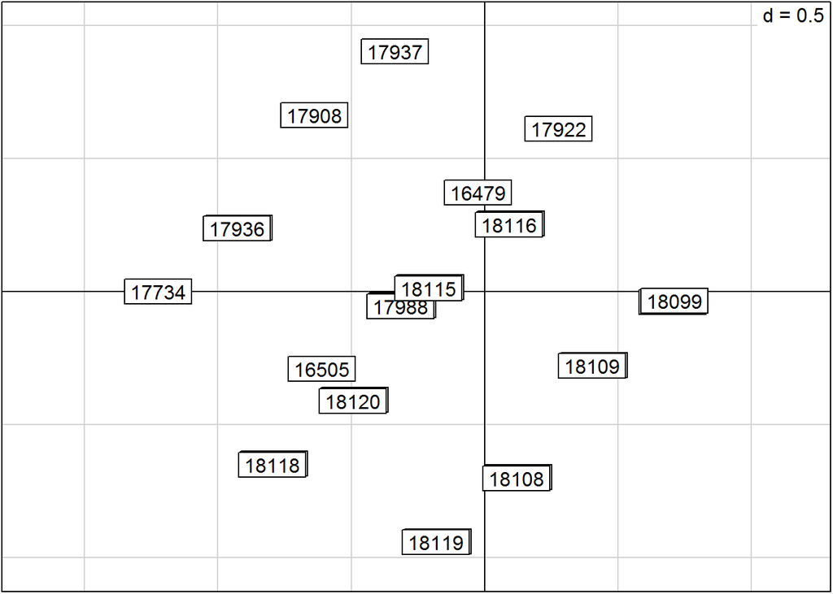

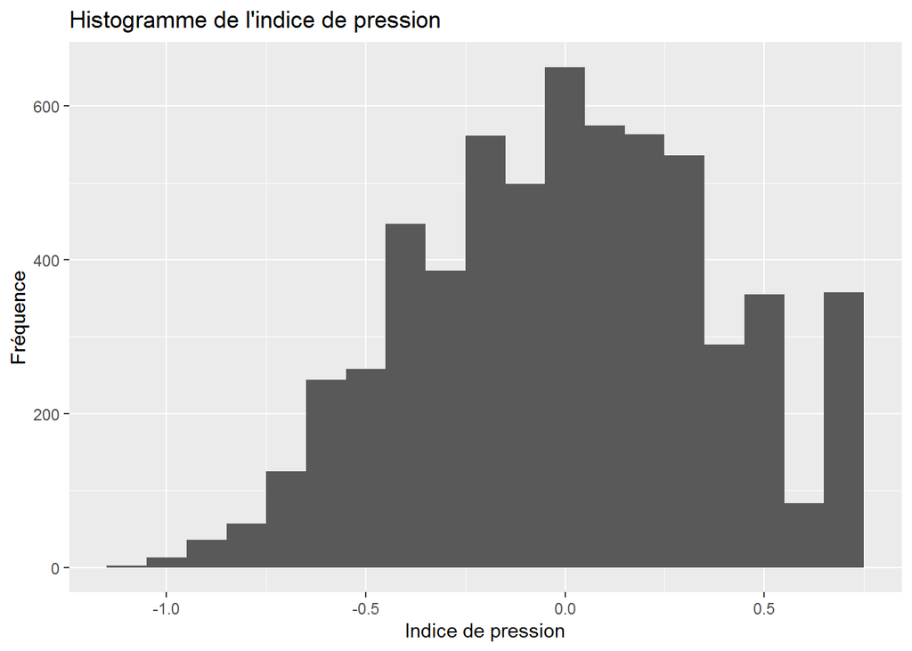

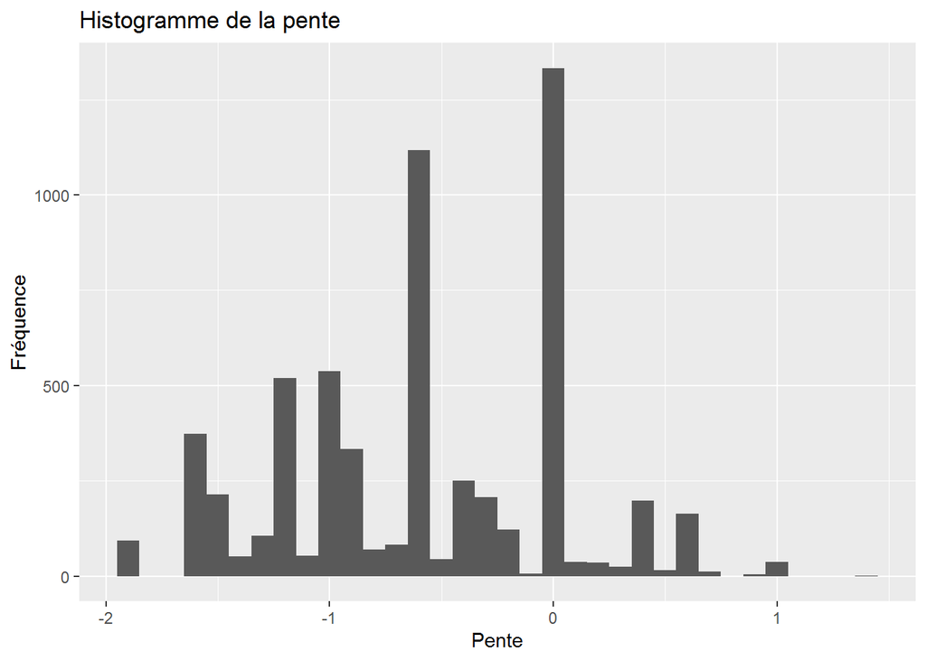

### Pressions chimiques (pollutions ponctuelles et pollutions diffuses)

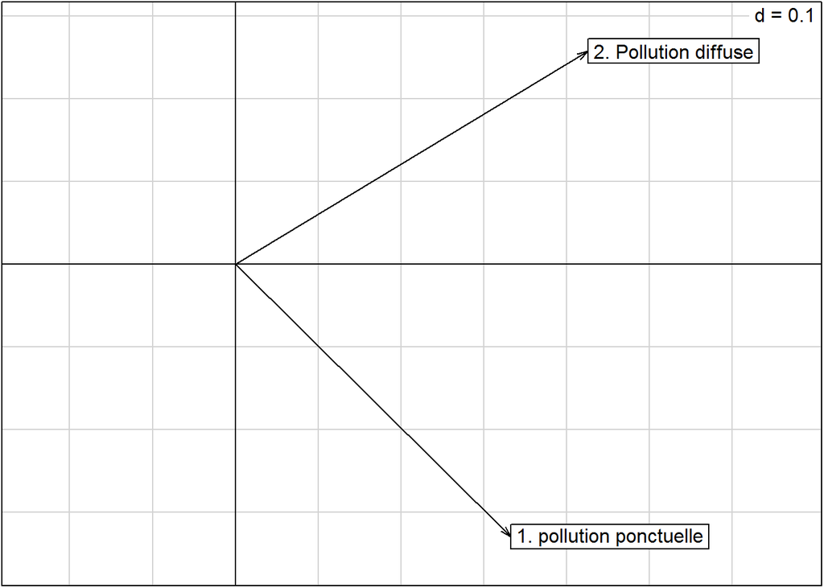

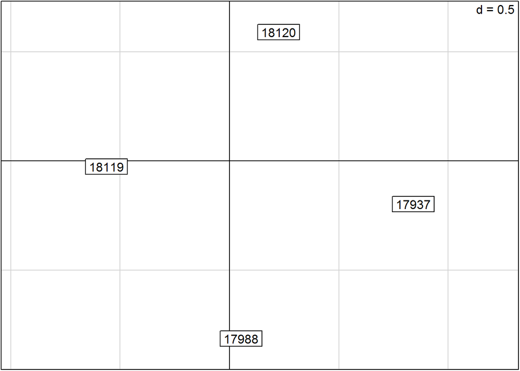

[figure not shown]

[figure not shown]

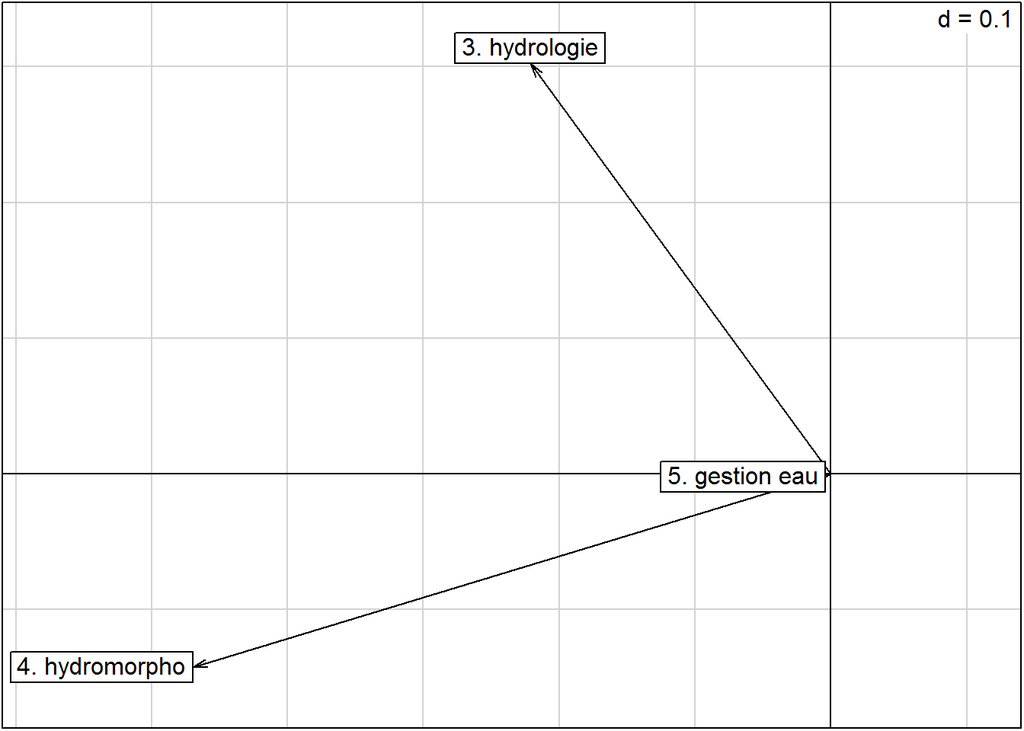

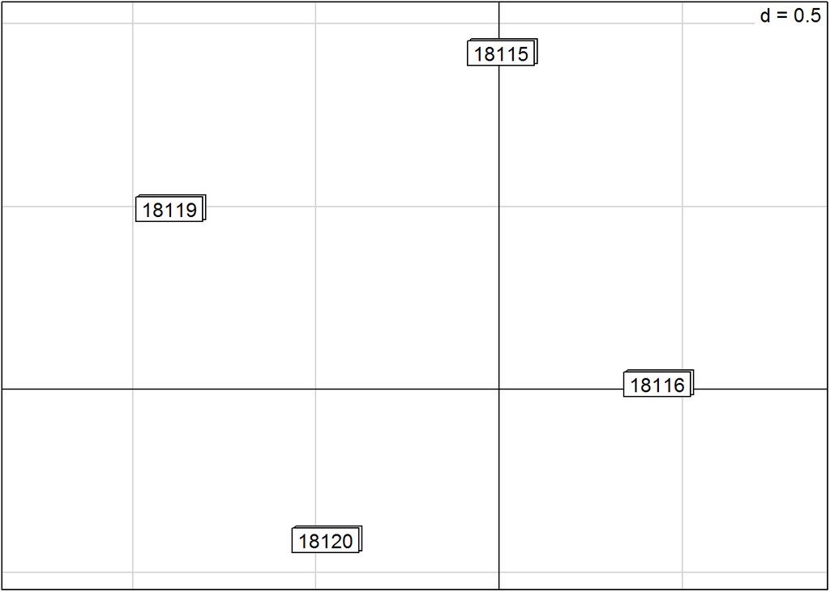

[figure not shown]

[figure not shown]